# Relatório Disciplina de R - Análises de Dados relacionados à Saúde

Ana Carolina, Ana Cecília, Karol, Laila, Nathan e Thaís

08/09/2021

# 1 Contextualização

Este relatório contém uma análise descritiva e exploratória de dados relacionados à saúde de alguns países da América do Sul. Foram extraídas informações de mortalidade infantil (1959 a 2009), expectativa de vida (1959 a 2009), gastos com saúde (1999 a 2009), proporção de médicos por habitante (1959 a 2009) e vacinação de crianças (1979 a 2009) da base de dados [Gapminder](https://www.gapminder.org/data/).  
Os países selecionados para análise foram: Brasil, Argentina, Bolívia, Colômbia, Peru, Uruguai, Paraguai, Venezuela, Suriname, Equador e Guiana.

# 2 Metodologia e Resultados

## 2.1 Baixando os bancos de dados do Gapminder

[Child Mortality](https://gapm.io/du5mr_gm_v11)  
[Life Expectancy](https://gapm.io/dlex_gm_v11)  
[Vaccination rate](http://gapm.io/dvacc_for_1yr)  
[Total Health Spendind (% of GDP)](https://www.who.int/data/gho)  
[Medical Doctors per 1000 people](https://data.worldbank.org/indicator/SH.MED.PHYS.ZS)

## 2.2 Carregando as bibliotecas utilizadas

```r
library(readr)
library(tidyverse)
library(lemon)
library(cowplot)
library(rmarkdown)
```

## 2.3 Carregando os bancos de dados

```r
child_mortality <- read_csv("child_mortality_0_5_year_olds_dying_per_1000_born.csv")
health_spending <- read_csv("total_health_spending_percent_of_gdp.csv")
vacc_rate <- read_csv("vacc_rate.csv")
medical_doctors <- read_csv("medical_doctors_per_1000_people.csv")
life_expectancy <- read_csv("life_expectancy_years.csv")
```

## 2.4 Colocando o nome da primeira coluna como ‘Country’

```r
colnames(child_mortality)[1] <- "Country"
colnames(health_spending)[1] <- "Country"
colnames(vacc_rate)[1] <- "Country"
colnames(medical_doctors)[1] <- "Country"
colnames(life_expectancy)[1] <- "Country"
```

## 2.5 Criando um vetor contendo o nome dos países da América Latina selecionados

```r
paises_al <- c("Brazil|Argentina|Bolivia|Colombia|Peru|Uruguay|Paraguay|Venezuela|Suriname|Ecuador|Guyana")
```

## 2.6 Filtrando o banco de dados por países da América Latina e por ano

```r
cm <- child_mortality %>%
    select(c("Country", '1959':'2009')) %>%
    filter(str_detect(Country, paises_al))
hs <- health_spending%>%
    select(c("Country", '1999':'2009')) %>%
    filter(str_detect(Country, paises_al))
md <- medical_doctors%>%
    select(c("Country", '1959':'2009')) %>%
    filter(str_detect(Country, paises_al))
vr <- vacc_rate%>%
    select(c("Country", '1979':'2009')) %>%
    filter(str_detect(Country, paises_al))
lf <- life_expectancy %>%
    select(c("Country", '1959':'2009')) %>%
    filter(str_detect(Country, paises_al))
```

## 2.7 Juntando os bancos de dados em um só arquivo

```r
db_joined <- lapply(1:5, function(x){vetores <- list(cm, hs, lf, md, vr);
xtype <- c("cm", "hs", "lf", "md", "vr");
vetores[[x]] %>% mutate(type = xtype[x])}) %>%
    bind_rows() %>%  select(Country, type, everything()) %>%
    pivot_longer(cols = -c("Country", "type"), names_to = "ano", values_to = "valores")
```

## 2.8 Visualização do banco de dados formatado

```r
paged_table(db_joined)
```

| Country | type | ano | valores |
| --- | --- | --- | --- |
| Argentina | cm | 1959 | 73.300 |
| Argentina | cm | 1960 | 69.000 |
| Argentina | cm | 1961 | 64.900 |
| Argentina | cm | 1962 | 61.100 |
| Argentina | cm | 1963 | 57.500 |
| Argentina | cm | 1964 | 57.500 |
| Argentina | cm | 1965 | 58.700 |
| Argentina | cm | 1966 | 58.600 |
| Argentina | cm | 1967 | 63.800 |
| Argentina | cm | 1968 | 72.800 |

[output cut: 2795 more lines]

## 2.9 Geração dos gráficos por dataset evidenciando a evolução dos países

O pacote `ggplot2` foi utilizado para gerar os gráficos neste relatório. A função `geom_smooth` foi escolhida para ver a tendência dos gráficos, uma vez que foi observada falta de informações (`NA`) em muitos casos.

### 2.9.1 Child Mortality

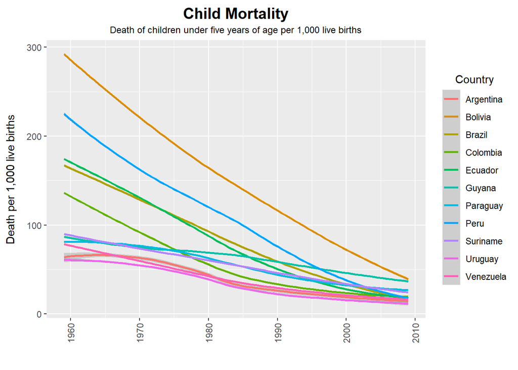

```r
cm_plot <-
    db_joined %>% filter(type == "cm") %>%
    ggplot(aes(x=as.integer(ano), y= valores, col= Country), data = .) +
    geom_smooth() +
    labs(title = "Child Mortality",
         x = "",
         y = "Death per 1,000 live births",
         subtitle = "Death of children under five years of age per 1,000 live births") +
    theme(plot.title = element_text(vjust = 0.5, hjust = 0.5, face = "bold", size = 15),
          axis.title.y = element_text(margin = margin(t = 0, r = 10, b = 0, l = 0)),
          axis.title.x = element_text(margin = margin(t = 10, r = 0, b = 0, l = 0)),
          axis.text.x = element_text(angle = 90, vjust = 0.5),
          legend.title.align = 0.5,
          plot.subtitle = element_text(hjust=0.5, size = 9))
cm_plot
```

É possível observar que ao longo do tempo, todos os países apresentaram uma queda na mortalidade infantil, principalmente os países Bolívia e Peru.

### 2.9.2 Health spending

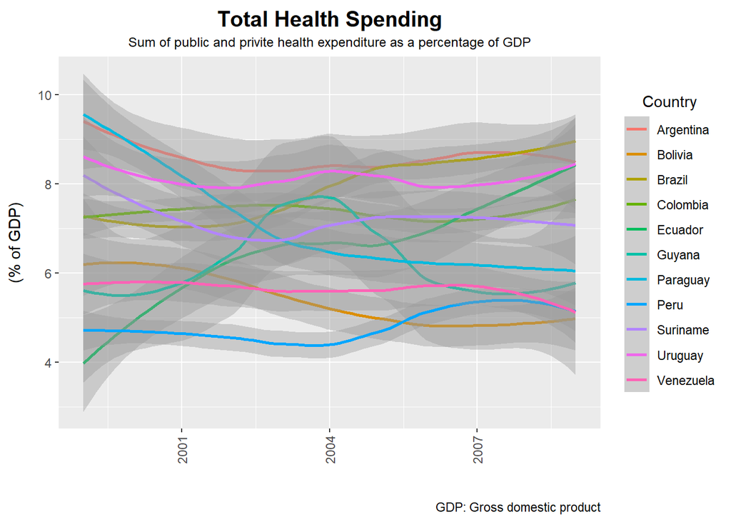

```r
hs_plot <-
    db_joined %>% filter(type == "hs") %>%
    ggplot(aes(x=as.integer(ano), y= valores, col= Country), data = .) +
    geom_smooth() +
    labs(title = "Total Health Spending",
         x = "",
         y = "(% of GDP)",
         subtitle = "Sum of public and privite health expenditure as a percentage of GDP",
         caption = "GDP: Gross domestic product") +
    theme(plot.title = element_text(vjust = 0.5, hjust = 0.5, face = "bold", size = 15),
          axis.title.y = element_text(margin = margin(t = 0, r = 10, b = 0, l = 0)),
          axis.title.x = element_text(margin = margin(t = 10, r = 0, b = 0, l = 0)),
          axis.text.x = element_text(angle = 90, vjust = 0.5),
          legend.title.align = 0.5,
          plot.subtitle = element_text(hjust=0.5, size = 9))
hs_plot
```

Com relação aos gastos totais em saúde, é possível observar que para muitos países não houve muita diferença ao longo dos anos, ele tendeu a ser relativamente estável. Um caso interessante de ser avaliado é o do Equador, que ao longo do tempo passou de 4 para 8.

### 2.9.3 Life expectancy

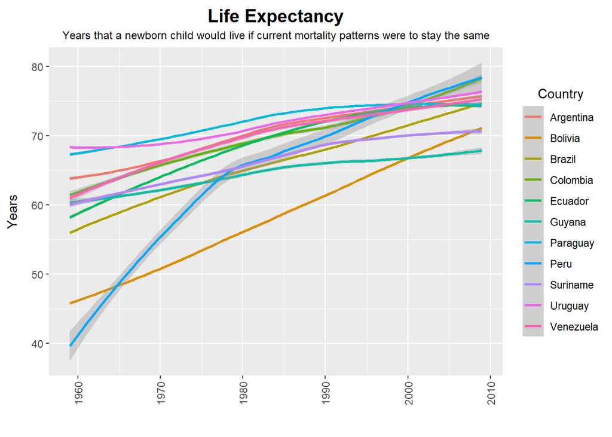

```r
lf_plot <-
    db_joined %>% filter(type == "lf") %>%
    ggplot(aes(x=as.integer(ano), y= valores, col= Country), data = .) +
    geom_smooth() +
    labs(title = "Life Expectancy",
         x = "",
         y = "Years",
         subtitle = "Years that a newborn child would live if current mortality patterns were to stay the same") +
    theme(plot.title = element_text(vjust = 0.5, hjust = 0.5, face = "bold", size = 15),
          axis.title.y = element_text(margin = margin(t = 0, r = 10, b = 0, l = 0)),
          axis.title.x = element_text(margin = margin(t = 10, r = 0, b = 0, l = 0)),
          axis.text.x = element_text(angle = 90, vjust = 0.5),
          legend.title.align = 0.5,
          plot.subtitle = element_text(hjust=0.5, size = 9))
lf_plot
```

Com relação à expectativa de vida, observa-se que todos os países apresentaram uma tendência de alta, com destaque para Peru e Bolívia.

### 2.9.4 Medical doctors

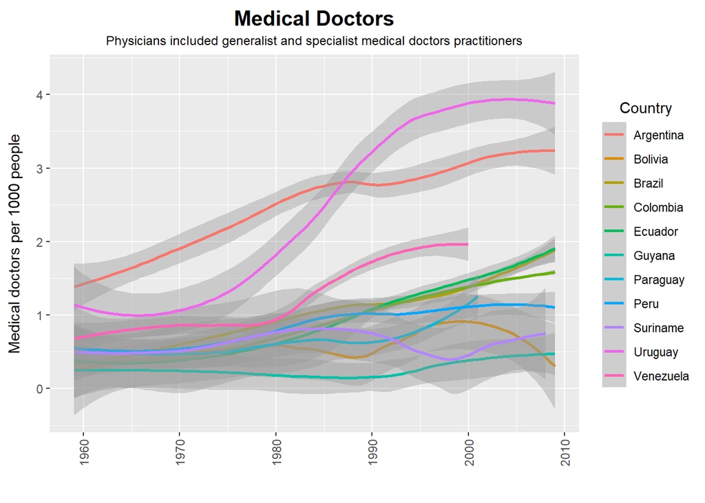

```r
md_plot <-
    db_joined %>% filter(type == "md") %>%
    ggplot(aes(x=as.integer(ano), y= valores, col= Country), data = .) +
    geom_smooth() +
    labs(title = "Medical Doctors",
         x = "",
         y = "Medical doctors per 1000 people",
         subtitle = "Physicians included generalist and specialist medical doctors practitioners") +
    theme(plot.title = element_text(vjust = 0.5, hjust = 0.5, face = "bold", size = 15),
          axis.title.y = element_text(margin = margin(t = 0, r = 10, b = 0, l = 0)),
          axis.title.x = element_text(margin = margin(t = 10, r = 0, b = 0, l = 0)),
          axis.text.x = element_text(angle = 90, vjust = 0.5),
          legend.title.align = 0.5,
          plot.subtitle = element_text(hjust=0.5, size = 9))
md_plot
```

Já com relação ao número de médicos por 1000 pessoas, os resultados foram um pouco mais misturados. É possível observar que alguns, ao longo do tempo, mantiveram estáveis os números enquanto outros houve aumento do número de médicos. Os países que apresentaram um maior aumento foram: Uruguai, Argentina e Venezuela, embora só tivesse dados disponíveis desse último até o ano de 2000.

### 2.9.5 Vaccination rate

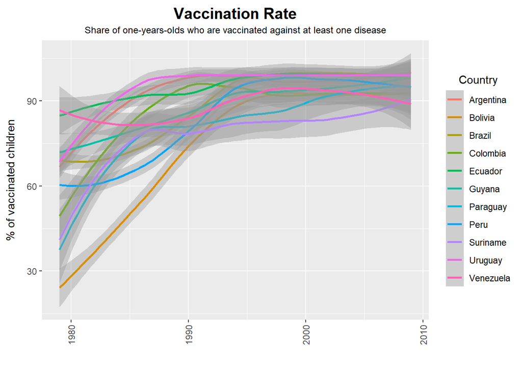

```r
vr_plot <-
    db_joined %>% filter(type == "vr") %>%
    ggplot(aes(x=as.integer(ano), y= valores, col= Country), data = .) +
    geom_smooth() +
    labs(title = "Vaccination Rate",
         x = "",
         y = "% of vaccinated children",
         subtitle = "Share of one-years-olds who are vaccinated against at least one disease") +
    theme(plot.title = element_text(vjust = 0.5, hjust = 0.5, face = "bold", size = 15),
          axis.title.y = element_text(margin = margin(t = 0, r = 10, b = 0, l = 0)),
          axis.title.x = element_text(margin = margin(t = 10, r = 0, b = 0, l = 0)),
          axis.text.x = element_text(angle = 90, vjust = 0.5),
          legend.title.align = 0.5,
          plot.subtitle = element_text(hjust=0.5, size = 9))
vr_plot
```

Nesse gráfico que mostra a % de vacinação em crianças vemos que assim como outros indicadores, em todos os países há um aumento do número ao longo dos anos. Importante ressaltar a evolução da Bolívia que em 1979 tinha apenas 30% das suas crianças vacinadas e no ano de 2010 estava próxima de 90%.

## 2.10 Extraindo a legenda de um dos gráficos para usar no gráfico compilado

```r
legend <- g_legend(cm_plot + theme(legend.position='left'))
```

## 2.11 Gerando o gráfico com todos os dados trabalhados

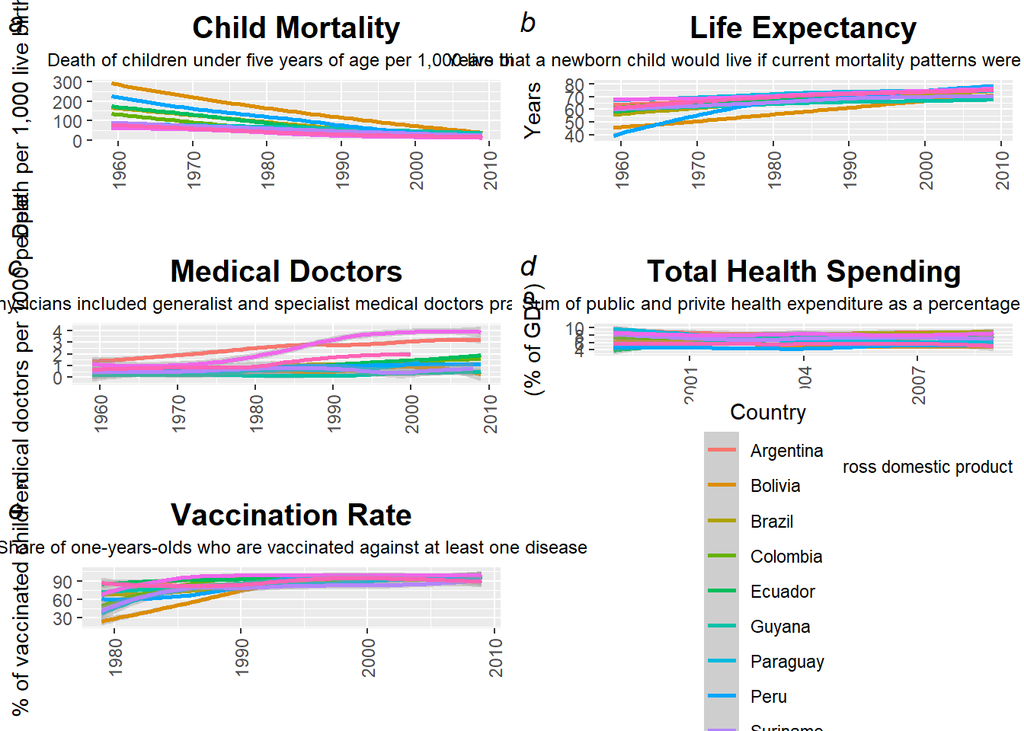

```r
plot_grid(cm_plot +
                  theme(legend.position='hidden'),
              lf_plot +
                  theme(legend.position='hidden'),
              md_plot +
                  theme(legend.position='hidden'),
              hs_plot +
                  theme(legend.position='hidden'),
              vr_plot +
                  theme(legend.position='hidden'),
              labels = c("a", "b", "c", "d", "e"),
              label_fontface = "italic",
              ncol =2,
              legend)
```

## 2.12 Salvando em .pdf

```r
ggsave("all_graphics1.pdf", width = 28, height = 28, units = "cm")
```

# 3 Conclusão

Foi observada uma tendência de aumento da expectativa de vida e da vacinação de crianças, bem como diminuição na mortalidade infantil em todos os países. Os gastos com saúde e a proporção de médicos por habitante foi bastante variável, provavelmente por conta da grande quantidade de *missing values*.